# Performance Analytics - Finance Recipes

Menu

### Introduction

PerformanceAnalytics is a library designed to evaluate the performance and risk of financial assets/funds. The claimed goal of the package is to make it simple to ask and answer questions. There are some really useful features of the package that don’t require you to write a large amount of code. You can do most of the things showing in the package with Base R, but it makes some calculations really simple. We will work through a few of them.

So how is this different from [Quantmod](http://financerecipes.com/quantmod.html)? Quantmod is a great tool for quickly putting together a basic trading model and the nice looking charts. When it was released, one of the great benefits of the package was the ability to download data directly from the Yahoo or Google API. This has been supplanted by [Quandl](http://www.quandl.com) (you can find my writeup [here](http://financerecipes.com/quandl.html)), which greatly enhances the ability to download the necessary data. I would say that the benefits of PerformanceAnalytics are some basic functionality to be able to analyze the risk/return characteristics of stocks, or especially as to the performance of a fund manager. There isn’t really any new functionality here; it is just a wrapper to be able to compute a number of things (such as alpha and beta) and generate plots.

### Installing and Loading Data

So, to get started we need to install and load the packages.

```r
install.packages("PerformanceAnalytics")
library(PerformanceAnalytics)
library(Quandl) #for downloading our data
```

And, lets go ahead and download some data to work with. What I am downloading here are the S&P 500 Index as our benchmark along with some Merrill Lynch Bond Indices. (I know, thats not a good choice of a benchmark for bond funds, but this is to illustrate the usage) You will notice that we have collapsed this to monthly and transformed into returns. **Data for the package MUST be in return format.** Otherwise, the package will spit out some garbage; I had some issues with the package initially because of this. Because the S&P500 data has a longer time series, I want to also drop out all the observations that have a missing value.

```r
Quandl.api_key("W8WDsBsiE9HFJzySzLQ3")
data <- Quandl(c("YAHOO/INDEX_GSPC.6", #S&P 500 Index
                 "ML/EMCTRI", #Emerging Markets Corporate Bond Total Return Index
                 "ML/AATRI", #US AA Total Return Index
                 "ML/BBTRI", #US BB Bond Total Return Index
                 "ML/CCCTRI"),  #US CCC Bond Total Return Index
               collapse = "monthly", #Making into monthly data
               transform = "rdiff", #converting into return data
               type = "xts") #And making into an xts object
names(data) <- c("SP500", "EMCTRI", "MLBBTRI", "AATRI", "CCCTRI") #Renaming to make easier to read
```

Because the S&P500 data has a longer time series, I want to also drop out all the observations that have a missing value.

```r
data <- na.omit(data)
summary(data)
```

```
##      Index          SP500               EMCTRI
##  Min.   :1999   Min.   :-0.169425   Min.   :-0.193697
##  1st Qu.:2003   1st Qu.:-0.019949   1st Qu.:-0.001161
##  Median :2008   Median : 0.008358   Median : 0.008160
##  Mean   :2008   Mean   : 0.003339   Mean   : 0.006255
##  3rd Qu.:2012   3rd Qu.: 0.031732   3rd Qu.: 0.015554
##  Max.   :2016   Max.   : 0.107723   Max.   : 0.064473
##     MLBBTRI              AATRI               CCCTRI
##  Min.   :-0.057741   Min.   :-0.151306   Min.   :-0.227865
##  1st Qu.:-0.003198   1st Qu.:-0.004888   1st Qu.:-0.014729
##  Median : 0.004784   Median : 0.008562   Median : 0.008891
##  Mean   : 0.004285   Mean   : 0.005807   Mean   : 0.005889
##  3rd Qu.: 0.011770   3rd Qu.: 0.017135   3rd Qu.: 0.026396
##  Max.   : 0.053566   Max.   : 0.075898   Max.   : 0.196385
```

Now, we can use one of the basic R plotting functions with ts.plot(). This generates a messy plot and requires a fair amount of code to write it, in addition to the fact that there isn’t much information contained.

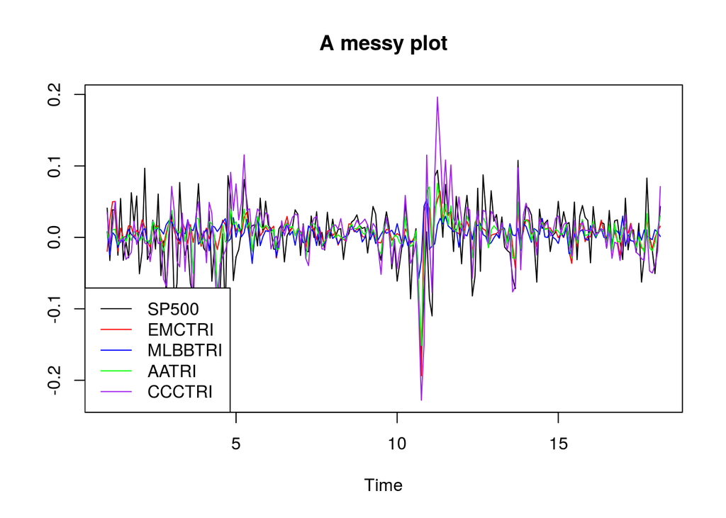

```r
ts.plot(data, col=c("black", "red", "blue", "green", "purple"), main="A messy plot")       #The plot
legend("bottomleft", names(data), col=c("black", "red", "blue", "green", "purple"), lty=1) #And the legend
```

### Charts with PerformanceAnalytics

We can use the below methods to generate an overlaid chart - chart.BarVaR() - or on separate charts - charts.BarVaR(). This tells us our Value-at-Risk and we can actually pass as an argument which method we want to use. You can find another reference [here.](http://www.inside-r.org/node/47859)

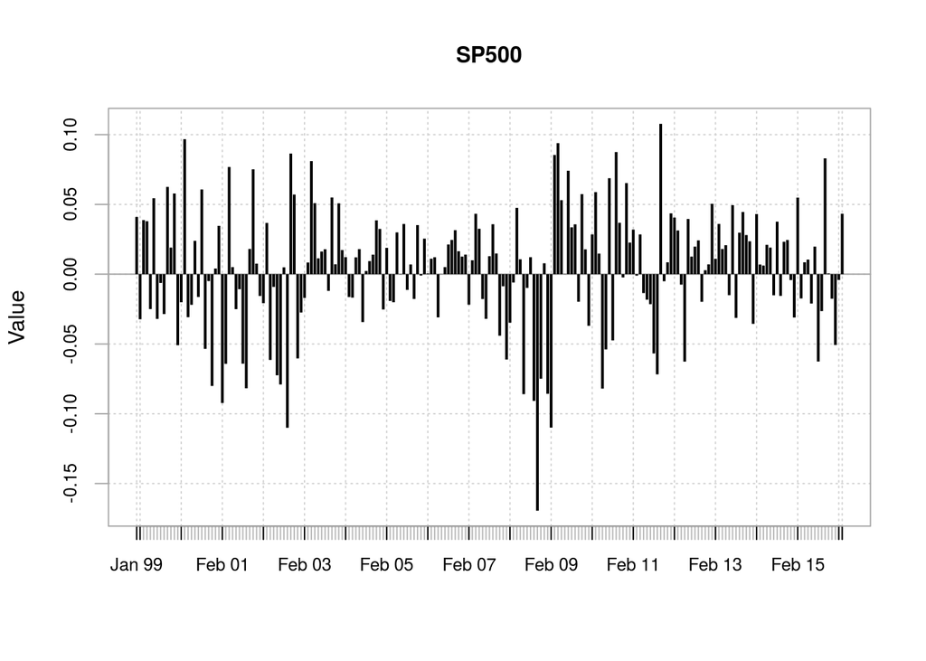

```r
chart.BarVaR(data)
```

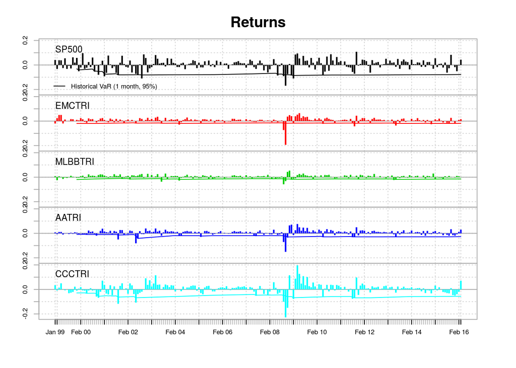

```r
charts.BarVaR(data,
              methods="HistoricalVaR")
```

We can also plot the cumulative returns and the drawdowns overlaid on each other.

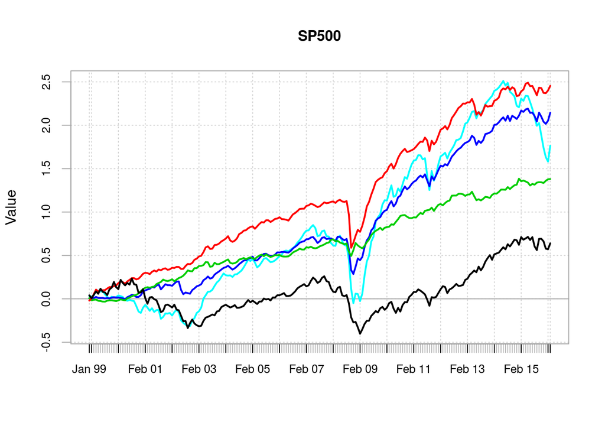

```r
chart.CumReturns(data)
```

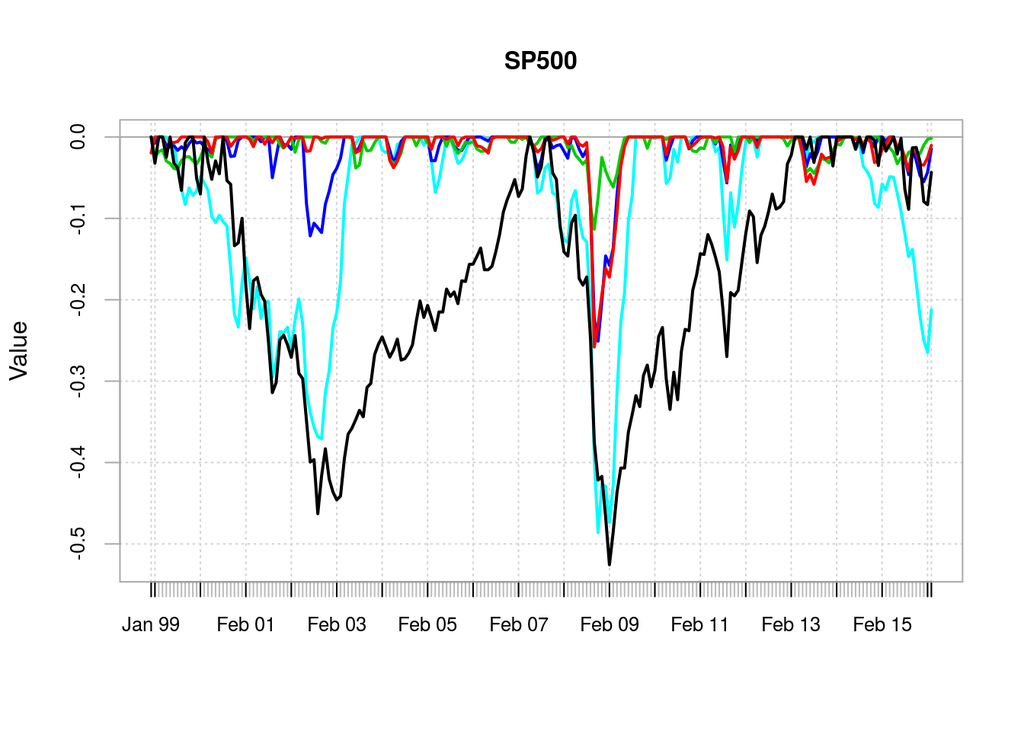

```r
chart.Drawdown(data)
```

Now, this is pretty neat and all, but what you probably wanted was a quick way to get right into it. We put all of this into one chart with the charts.PerformanceSummary() like below.

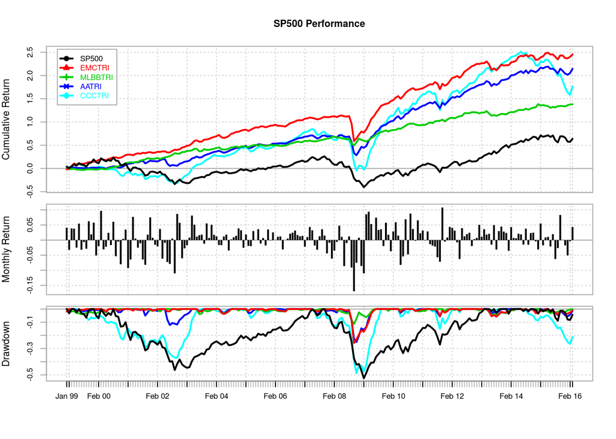

```r
charts.PerformanceSummary(data)
```

Plus, there are some other neat plotting functions like:

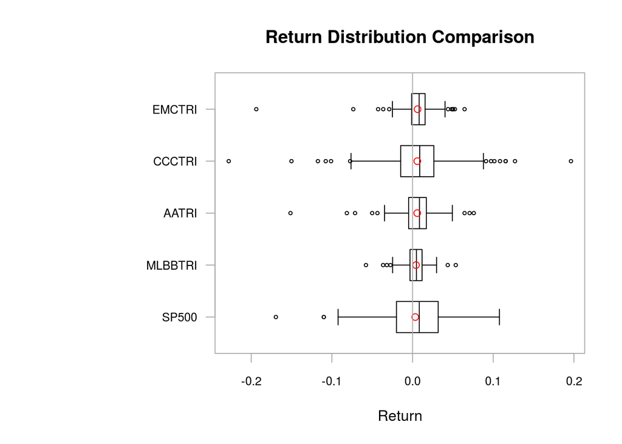

```r
chart.Boxplot(data)
```

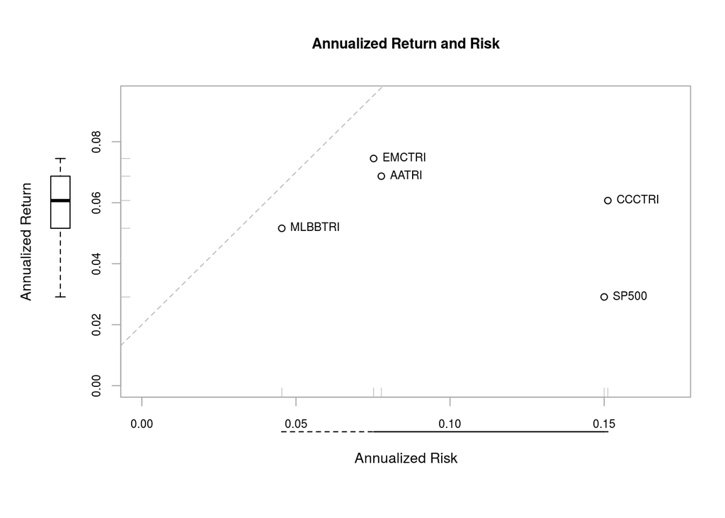

```r
chart.RiskReturnScatter(data, Rf = .02/12, add.sharpe = TRUE, add.boxplots = TRUE)
```

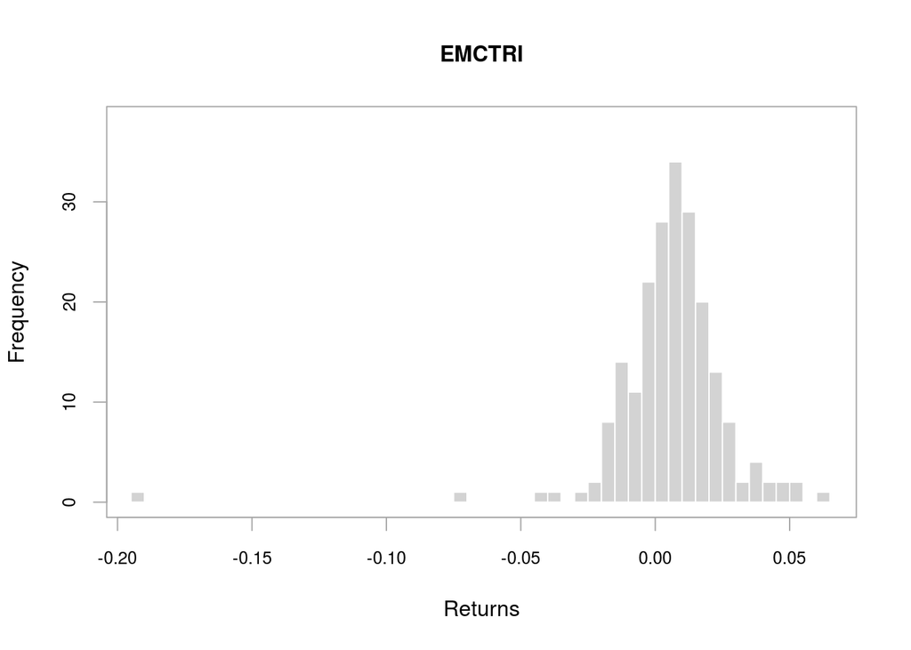

```r
chart.Histogram(data[,2])  #Shows the tail risk pretty clear, we call a single column
```

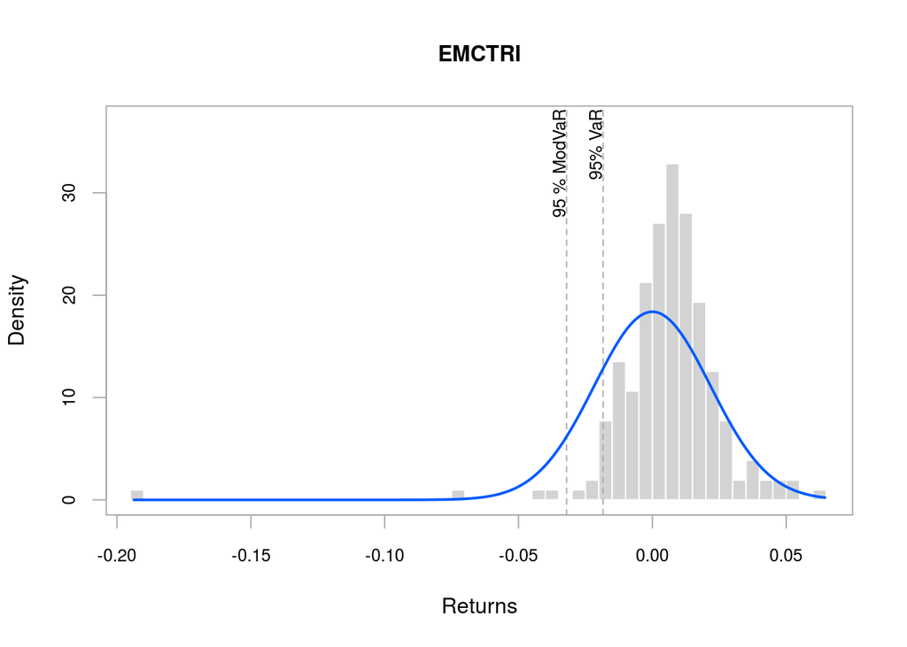

```r
chart.Histogram(data[,2], methods = c("add.risk", "add.centered")) #And why VaR is not as effective at controlling the substantial downside risk
```

### CAPM Calculations

There are some other pretty good tools for computing CAPM alphas and betas. We can compute these factors to see if a particular manager has acheived alpha(negative or postive). In the below calculations, we will be working with individual stock data - specifically Apple, Microsoft, Tesla, and GE, along with the S&P 500 as the benchmark/market return. One nice feature PerformanceAnalytics does not have is the ability to compute the Fama-French factor loadings. While its not that difficult to compute them, it would be nice - [Fama-French Calculations](http://financerecipes.com/fama-french.html)  
So, we start off by downloading the data in monthly returns and xts, then removing any NAs.

```r
stockData <- Quandl(c("WIKI/AAPL.11", "WIKI/MSFT.11", "WIKI/TSLA.11", "WIKI/GE.11", "YAHOO/INDEX_GSPC.6"), collapse="monthly", transform="rdiff", type="xts")
stockData <- na.omit(stockData)
names(stockData) <- c("AAPL", "MSFT", "TSLA", "GE", "SP500")
head(stockData)
```

```
##                 AAPL        MSFT        TSLA          GE       SP500
## Jul 2010  0.02274083  0.12168622 -0.16323961  0.11789182  0.06877785
## Aug 2010 -0.05500486 -0.08587848 -0.02306921 -0.10173697 -0.04744918
## Sep 2010  0.16721514  0.04345974  0.04774127  0.13053507  0.08755110
## Oct 2010  0.06072247  0.08901592  0.07006369 -0.01415385  0.03685599
## Nov 2010  0.03378962 -0.04699698  0.61767399 -0.01186017 -0.00229025
## Dec 2010  0.03667042  0.10490895 -0.24624965  0.16435774  0.06530004
```

```r
summary(stockData)
```

```
##      Index           AAPL               MSFT               TSLA
##  Min.   :2010   Min.   :-0.14409   Min.   :-0.13025   Min.   :-0.246250
##  1st Qu.:2012   1st Qu.:-0.02492   1st Qu.:-0.03224   1st Qu.:-0.071448
##  Median :2013   Median : 0.01085   Median : 0.01856   Median : 0.003818
##  Mean   :2013   Mean   : 0.01920   Mean   : 0.01655   Mean   : 0.045898
##  3rd Qu.:2015   3rd Qu.: 0.07007   3rd Qu.: 0.05326   3rd Qu.: 0.114743
##  Max.   :2016   Max.   : 0.18831   Max.   : 0.19641   Max.   : 0.810706
##        GE                SP500
##  Min.   :-0.103461   Min.   :-0.07176
##  1st Qu.:-0.031903   1st Qu.:-0.01508
##  Median : 0.007416   Median : 0.01106
##  Mean   : 0.015317   Mean   : 0.01041
##  3rd Qu.: 0.048247   3rd Qu.: 0.03196
##  Max.   : 0.164358   Max.   : 0.10772
```

We now can compute the betas on each of the stocks using CAPM.beta() and CAPM.alpha(). The first required argument is the vector(s) you are computing on, second column is the vector of the benchmmark, and the third being the risk-free rate. For this example we are using a 2% annual rate and insert ( Rf=0.02/12 ) divided by 12 to adjust it to a monthly risk-free rate. One thing you will need to watch out for when calculating these is that they do not display the statistical significance. This isn’t a huge issue for Beta, but it definitely is for computing alpha. We don’t know if the positive or negative value displayed by CAPM.alpha() is statistically different from zero.

```r
stocks <- stockData[,1:4]
mkt <- stockData[,5]
CAPM.beta(stocks, mkt, Rf=0.02/12)
```

```
##                  AAPL     MSFT      TSLA       GE
## Beta: SP500 0.9875436 1.009824 0.6204877 1.306023
```

```r
CAPM.alpha(stocks, mkt, Rf=0.02/12)
```

```
##                     AAPL        MSFT       TSLA          GE
## Alpha: SP500 0.008900823 0.006052579 0.03880699 0.002232203
```

We can also compute the slope of the Capital Markets Line (CML) and the risk premium. What this risk premium measures shows is how much return we would actually be gaining above the risk-free rate. If this value is negative, it means that we shouldn’t have been holding this asset as there was not enough compensation for the risk taken.

```r
CAPM.CML.slope(mkt, Rf=0.02/12)
```

```
##                                     SP500
## Capital Market Line Slope: SP500 0.241552
```

```r
CAPM.RiskPremium(stockData[,1:4], Rf=0.02/12)
```

```
##                              AAPL       MSFT       TSLA         GE
## Risk Premium (Rf=0.2%) 0.01753451 0.01488106 0.04423166 0.01365023
```

We are also able to summarise the above information much quicker by calculating a couple tables.

```r
#The below table also gives everything we could want on those factors.
table.CAPM(stocks, mkt, Rf = 0.02/12)
```

```
##                     AAPL to SP500 MSFT to SP500 TSLA to SP500 GE to SP500
## Alpha                      0.0089        0.0061        0.0388      0.0022
## Beta                       0.9875        1.0098        0.6205      1.3060
## Beta+                      0.8609        0.9642       -0.6454      1.2166
## Beta-                      0.1809        0.6532        2.8899      0.8781
## R-squared                  0.2514        0.3181        0.0158      0.5992
## Annualized Alpha           0.1122        0.0751        0.5791      0.0271
## Correlation                0.5014        0.5640        0.1258      0.7741
## Correlation p-value        0.0000        0.0000        0.3029      0.0000
## Tracking Error             0.2136        0.1854        0.6152      0.1393
## Active Premium             0.0966        0.0654        0.3462      0.0512
## Information Ratio          0.4522        0.3529        0.5628      0.3676
## Treynor Ratio              0.1990        0.1643        0.7114      0.1163
```

```r
table.Correlation(stocks, mkt, Rf = 0.02/12)
```

```
##               Correlation      p-value   Lower CI  Upper CI
## AAPL to SP500   0.5014461 1.138668e-05  0.3004201 0.6598179
## MSFT to SP500   0.5639668 4.507676e-07  0.3777017 0.7063622
## TSLA to SP500   0.1258267 3.029151e-01 -0.1142566 0.3520239
## GE to SP500     0.7740850 6.196962e-15  0.6579476 0.8542565
```

While the CAPM factors are not perfect, there are some other factors outside of standard deviation we can use to [calculate the downside risk.](http://down.cenet.org.cn/upfile/36/2006110111543100.pdf) Of course, the reason we want to calculate the downside risk is that volatility on the upside is not of concern - we really are concerned about what we could lose. Below are two ways to calculate this downside risk.

```r
#Calculating Downside risk
SemiDeviation(stockData[,1])
```

```
##                      AAPL
## Semi-Deviation 0.04980317
```

```r
#A more general case Sortino and Price(1994)
DownsideDeviation(stockData[,1], MAR=0)
```

```
## [1] 0.03963306
```

And, we can naturally create a table to show us all the relevant information

```r
table.DownsideRisk(stockData, Rf=0.03/12) #Rf is optional
```

```
##                                 AAPL    MSFT    TSLA      GE   SP500
## Semi Deviation                0.0498  0.0427  0.1011  0.0403  0.0256
## Gain Deviation                0.0481  0.0476  0.1664  0.0443  0.0235
## Loss Deviation                0.0407  0.0300  0.0695  0.0281  0.0206
## Downside Deviation (MAR=10%)  0.0438  0.0381  0.0786  0.0361  0.0245
## Downside Deviation (Rf=3%)    0.0409  0.0349  0.0755  0.0328  0.0214
## Downside Deviation (0%)       0.0396  0.0335  0.0741  0.0315  0.0202
## Maximum Drawdown              0.3954  0.1568  0.3418  0.2597  0.1703
## Historical VaR (95%)         -0.1077 -0.0760 -0.1705 -0.0699 -0.0544
## Historical ES (95%)          -0.1202 -0.0942 -0.2067 -0.0918 -0.0634
## Modified VaR (95%)           -0.0972 -0.0795 -0.1377 -0.0784 -0.0484
## Modified ES (95%)            -0.1238 -0.0989 -0.3243 -0.0948 -0.0639
```

We can also pass just a single vector into the table function

```r
table.DownsideRisk(stockData[,1])
```

```
##                                 AAPL
## Semi Deviation                0.0498
## Gain Deviation                0.0481
## Loss Deviation                0.0407
## Downside Deviation (MAR=10%)  0.0438
## Downside Deviation (Rf=0%)    0.0396
## Downside Deviation (0%)       0.0396
## Maximum Drawdown              0.3954
## Historical VaR (95%)         -0.1077
## Historical ES (95%)          -0.1202
## Modified VaR (95%)           -0.0972
## Modified ES (95%)            -0.1238
```

```
I hope that overview of PerformanceAnalytics was helpful.
```